# 05.1_Data_Exploration_Numerical

- The IRIS dataset:
  - Load the dataset
  - Explore the dataset: Descriptive statistics
  - Explore the dataset: Visualization

```python
import os
import pandas as pd
```

# The IRIS dataset

This is perhaps the best known database to be found in the pattern recognition literature.

- The data set contains 3 classes of 50 instances each, where each class refers to a type of iris plant.
- There are four numeric attributes and the class attribute:
  1. sepal length in cm
  2. sepal width in cm
  3. petal length in cm
  4. petal width in cm
  5. class: {Iris Setosa, Iris Versicolour, Iris Virginica}

[figure not shown]

## Load the dataset

Common pitfalls in `pd.read_csv`:

- what is the "sep" character
- is there any header?
- is there any index column?
- how are missing/unknown values denoted?

```python
iris_df = pd.read_csv(os.path.join('dataset','iris.csv'))
```

## Explore the dataset: descriptive statistics

```python
iris_df
```

|  | sepallength | sepalwidth | petallength | petalwidth | class |
| --- | --- | --- | --- | --- | --- |
| 0 | 5.1 | 3.5 | 1.4 | 0.2 | 1 |
| 1 | 4.9 | 3.0 | 1.4 | 0.2 | 1 |
| 2 | 4.7 | 3.2 | 1.3 | 0.2 | 1 |
| 3 | 4.6 | 3.1 | 1.5 | 0.2 | 1 |
| 4 | 5.0 | 3.6 | 1.4 | 0.2 | 1 |
| ... | ... | ... | ... | ... | ... |
| 145 | 6.7 | 3.0 | 5.2 | 2.3 | 3 |
| 146 | 6.3 | 2.5 | 5.0 | 1.9 | 3 |
| 147 | 6.5 | 3.0 | 5.2 | 2.0 | 3 |
| 148 | 6.2 | 3.4 | 5.4 | 2.3 | 3 |
| 149 | 5.9 | 3.0 | 5.1 | 1.8 | 3 |

150 rows × 5 columns

```python
iris_df.shape
```

```
(150, 5)
```

```python
pd.set_option('display.max_rows', 150)
iris_df
```

|  | sepallength | sepalwidth | petallength | petalwidth | class |
| --- | --- | --- | --- | --- | --- |
| 0 | 5.1 | 3.5 | 1.4 | 0.2 | 1 |
| 1 | 4.9 | 3.0 | 1.4 | 0.2 | 1 |
| 2 | 4.7 | 3.2 | 1.3 | 0.2 | 1 |
| 3 | 4.6 | 3.1 | 1.5 | 0.2 | 1 |
| 4 | 5.0 | 3.6 | 1.4 | 0.2 | 1 |
| 5 | 5.4 | 3.9 | 1.7 | 0.4 | 1 |
| 6 | 4.6 | 3.4 | 1.4 | 0.3 | 1 |
| 7 | 5.0 | 3.4 | 1.5 | 0.2 | 1 |
| 8 | 4.4 | 2.9 | 1.4 | 0.2 | 1 |
| 9 | 4.9 | 3.1 | 1.5 | 0.1 | 1 |
| 10 | 5.4 | 3.7 | 1.5 | 0.2 | 1 |
| 11 | 4.8 | 3.4 | 1.6 | 0.2 | 1 |
| 12 | 4.8 | 3.0 | 1.4 | 0.1 | 1 |
| 13 | 4.3 | 3.0 | 1.1 | 0.1 | 1 |
| 14 | 5.8 | 4.0 | 1.2 | 0.2 | 1 |
| 15 | 5.7 | 4.4 | 1.5 | 0.4 | 1 |
| 16 | 5.4 | 3.9 | 1.3 | 0.4 | 1 |
| 17 | 5.1 | 3.5 | 1.4 | 0.3 | 1 |
| 18 | 5.7 | 3.8 | 1.7 | 0.3 | 1 |
| 19 | 5.1 | 3.8 | 1.5 | 0.3 | 1 |
| 20 | 5.4 | 3.4 | 1.7 | 0.2 | 1 |
| 21 | 5.1 | 3.7 | 1.5 | 0.4 | 1 |
| 22 | 4.6 | 3.6 | 1.0 | 0.2 | 1 |
| 23 | 5.1 | 3.3 | 1.7 | 0.5 | 1 |
| 24 | 4.8 | 3.4 | 1.9 | 0.2 | 1 |
| 25 | 5.0 | 3.0 | 1.6 | 0.2 | 1 |
| 26 | 5.0 | 3.4 | 1.6 | 0.4 | 1 |
| 27 | 5.2 | 3.5 | 1.5 | 0.2 | 1 |
| 28 | 5.2 | 3.4 | 1.4 | 0.2 | 1 |
| 29 | 4.7 | 3.2 | 1.6 | 0.2 | 1 |

[output cut: 120 more lines]

```python
iris_df.head(10)
```

|  | sepallength | sepalwidth | petallength | petalwidth | class |
| --- | --- | --- | --- | --- | --- |
| 0 | 5.1 | 3.5 | 1.4 | 0.2 | 1 |
| 1 | 4.9 | 3.0 | 1.4 | 0.2 | 1 |
| 2 | 4.7 | 3.2 | 1.3 | 0.2 | 1 |
| 3 | 4.6 | 3.1 | 1.5 | 0.2 | 1 |
| 4 | 5.0 | 3.6 | 1.4 | 0.2 | 1 |
| 5 | 5.4 | 3.9 | 1.7 | 0.4 | 1 |
| 6 | 4.6 | 3.4 | 1.4 | 0.3 | 1 |
| 7 | 5.0 | 3.4 | 1.5 | 0.2 | 1 |
| 8 | 4.4 | 2.9 | 1.4 | 0.2 | 1 |
| 9 | 4.9 | 3.1 | 1.5 | 0.1 | 1 |

```python
iris_df.head(10).T
```

|  | 0 | 1 | 2 | 3 | 4 | 5 | 6 | 7 | 8 | 9 |
| --- | --- | --- | --- | --- | --- | --- | --- | --- | --- | --- |
| sepallength | 5.1 | 4.9 | 4.7 | 4.6 | 5.0 | 5.4 | 4.6 | 5.0 | 4.4 | 4.9 |
| sepalwidth | 3.5 | 3.0 | 3.2 | 3.1 | 3.6 | 3.9 | 3.4 | 3.4 | 2.9 | 3.1 |
| petallength | 1.4 | 1.4 | 1.3 | 1.5 | 1.4 | 1.7 | 1.4 | 1.5 | 1.4 | 1.5 |
| petalwidth | 0.2 | 0.2 | 0.2 | 0.2 | 0.2 | 0.4 | 0.3 | 0.2 | 0.2 | 0.1 |
| class | 1.0 | 1.0 | 1.0 | 1.0 | 1.0 | 1.0 | 1.0 | 1.0 | 1.0 | 1.0 |

Check if there is any missing value

```python
iris_df.isna().sum()
```

```
sepallength    0
sepalwidth     0
petallength    0
petalwidth     0
class          0
dtype: int64
```

```python
iris_df.describe()
```

|  | sepallength | sepalwidth | petallength | petalwidth | class |
| --- | --- | --- | --- | --- | --- |
| count | 150.000000 | 150.000000 | 150.000000 | 150.000000 | 150.000000 |
| mean | 5.843333 | 3.054000 | 3.758667 | 1.198667 | 2.000000 |
| std | 0.828066 | 0.433594 | 1.764420 | 0.763161 | 0.819232 |
| min | 4.300000 | 2.000000 | 1.000000 | 0.100000 | 1.000000 |
| 25% | 5.100000 | 2.800000 | 1.600000 | 0.300000 | 1.000000 |
| 50% | 5.800000 | 3.000000 | 4.350000 | 1.300000 | 2.000000 |
| 75% | 6.400000 | 3.300000 | 5.100000 | 1.800000 | 3.000000 |
| max | 7.900000 | 4.400000 | 6.900000 | 2.500000 | 3.000000 |

```python
iris_df.drop('class',axis = 1).describe()
```

|  | sepallength | sepalwidth | petallength | petalwidth |
| --- | --- | --- | --- | --- |
| count | 150.000000 | 150.000000 | 150.000000 | 150.000000 |
| mean | 5.843333 | 3.054000 | 3.758667 | 1.198667 |
| std | 0.828066 | 0.433594 | 1.764420 | 0.763161 |
| min | 4.300000 | 2.000000 | 1.000000 | 0.100000 |
| 25% | 5.100000 | 2.800000 | 1.600000 | 0.300000 |
| 50% | 5.800000 | 3.000000 | 4.350000 | 1.300000 |
| 75% | 6.400000 | 3.300000 | 5.100000 | 1.800000 |
| max | 7.900000 | 4.400000 | 6.900000 | 2.500000 |

```python
iris_df.info()
```

```
<class 'pandas.core.frame.DataFrame'>
RangeIndex: 150 entries, 0 to 149
Data columns (total 5 columns):
 #   Column       Non-Null Count  Dtype
---  ------       --------------  -----
 0   sepallength  150 non-null    float64
 1   sepalwidth   150 non-null    float64
 2   petallength  150 non-null    float64
 3   petalwidth   150 non-null    float64
 4   class        150 non-null    int64
dtypes: float64(4), int64(1)
memory usage: 6.0 KB
```

```python
iris_df['class'].value_counts()
```

```
class
1    50
2    50
3    50
Name: count, dtype: int64
```

## Explore the dataset: Visualization

```python
from matplotlib import pyplot as plt
```

### Histogram and boxplots with matplotlib

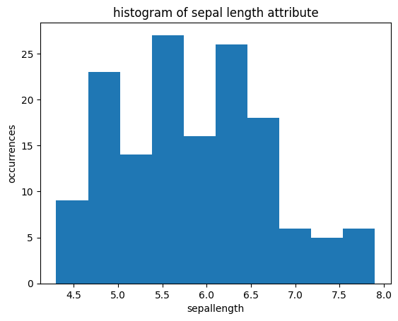

```python
plt.figure()
plt.hist(iris_df['sepallength'])
plt.ylabel('occurrences')
plt.xlabel('sepallength')
plt.title(f'histogram of sepal length attribute')
```

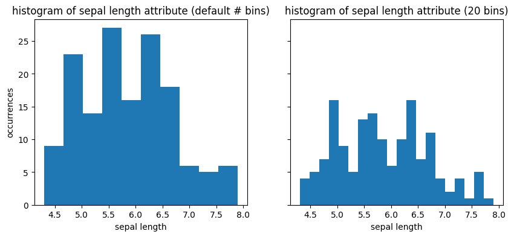

```python
f, axes = plt.subplots(1,2,sharey = True, figsize = (10,4))
axes[0].hist(iris_df['sepallength'])
axes[0].set_ylabel('occurrences')
axes[0].set_xlabel('sepal length')
axes[0].set_title(f'histogram of sepal length attribute (default # bins)')
axes[1].hist(iris_df['sepallength'],bins = 20)
axes[1].set_xlabel('sepal length')
axes[1].set_title(f'histogram of sepal length attribute (20 bins)')
plt.show()
```

### Histogram and boxplots with pandas

[Check the user guide](https://pandas.pydata.org/pandas-docs/stable/user_guide/visualization.html)

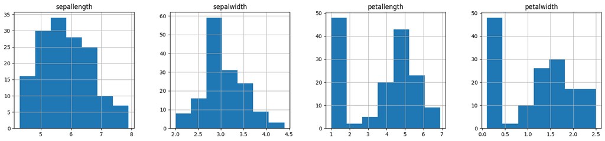

```python
iris_df.drop('class',axis = 1).hist(bins = 7,layout = (1,4),figsize = (20,4))
plt.show()
```

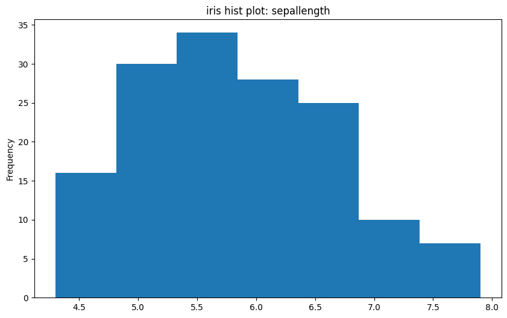

```python
iris_df['sepallength'].plot(kind='hist', bins=7, figsize=(10,6), title='iris hist plot: sepallength')
plt.show()
```

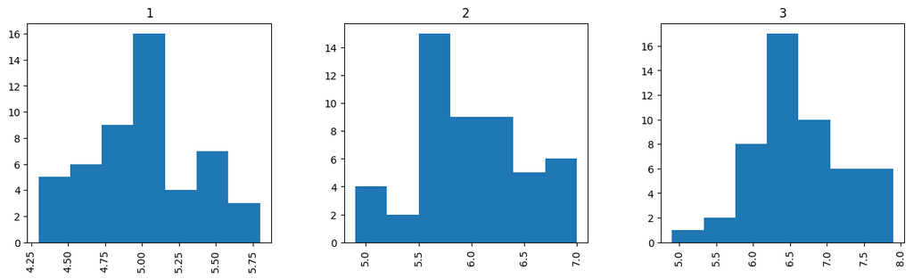

```python
iris_df.hist(column='sepallength', by='class', bins = 7, figsize=(15,4),layout = (1,3))
plt.show()
```

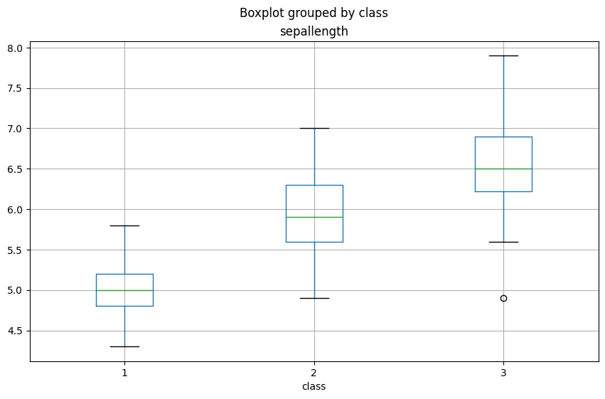

```python
iris_df.boxplot(column='sepallength', by='class', figsize=(10,6))
plt.show()
```

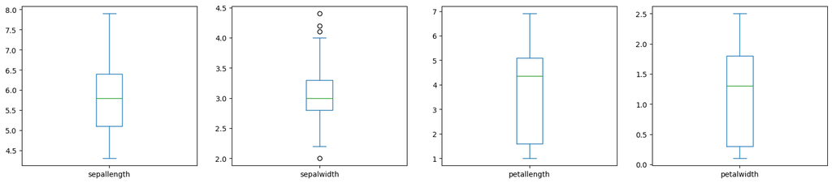

```python
iris_df.drop('class',axis = 1).plot(kind ='box',
                                    subplots = True,
                                    figsize=(20,4),
                                    layout = (1,4),
                                    sharey=False)
plt.show()
```

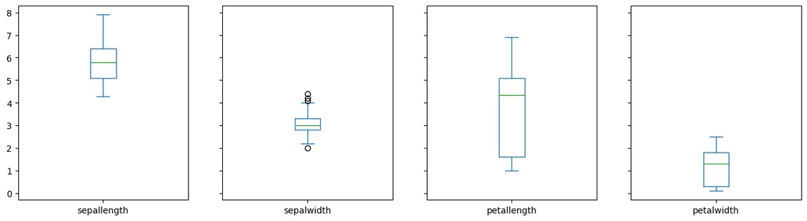

```python
iris_df.drop('class',axis = 1).plot(kind ='box',
                                    subplots = True,
                                    figsize=(16,4),
                                    layout = (1,4),
                                    sharey=True)
plt.show()
```

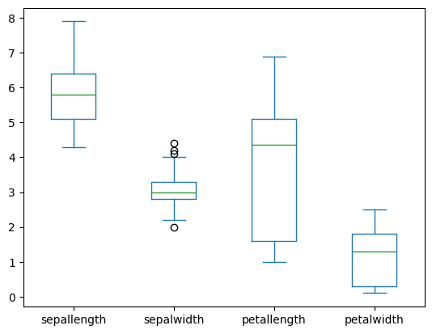

```python
iris_df.drop('class',axis = 1).plot(kind ='box')
plt.show()
```

### Scatter plot with matplotlib

```python
dict_names = {1:'Iris-setosa', 2:'Iris-versicolor', 3:'Iris-virginica'}
dict_names.values()
```

```
dict_values(['Iris-setosa', 'Iris-versicolor', 'Iris-virginica'])
```

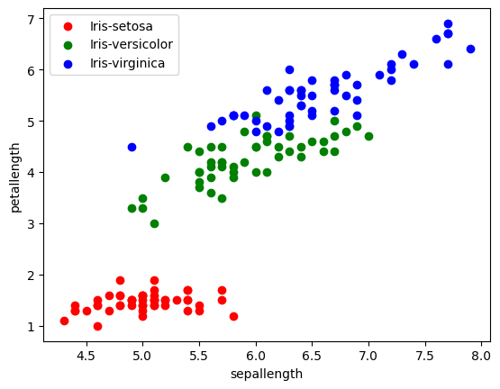

```python
x_index = 0
y_index = 2
for curr_class,color in zip(range(1,4),'rgb'):
    scatterplot = plt.scatter(iris_df[iris_df["class"] == curr_class].iloc[:,x_index],
                              iris_df[iris_df["class"] == curr_class].iloc[:,y_index],
                              c=color,
                              # here you can customize the marker size or style, for instance
                              label = dict_names[curr_class])
plt.xlabel(iris_df.columns[x_index])
plt.ylabel(iris_df.columns[y_index])
plt.legend()
plt.show()
```

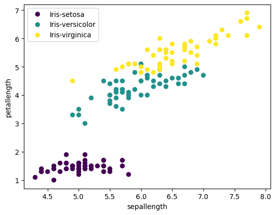

```python
# analogously: easier on the plotting stage, more complicated for handling legend elements.
x_index = 0
y_index = 2

scatterplot = plt.scatter(iris_df.iloc[:,x_index],iris_df.iloc[:,y_index], c=iris_df['class'])
plt.xlabel(iris_df.columns[x_index])
plt.ylabel(iris_df.columns[y_index])
plt.legend(handles=scatterplot.legend_elements()[0], labels=dict_names.values())
plt.show()
```

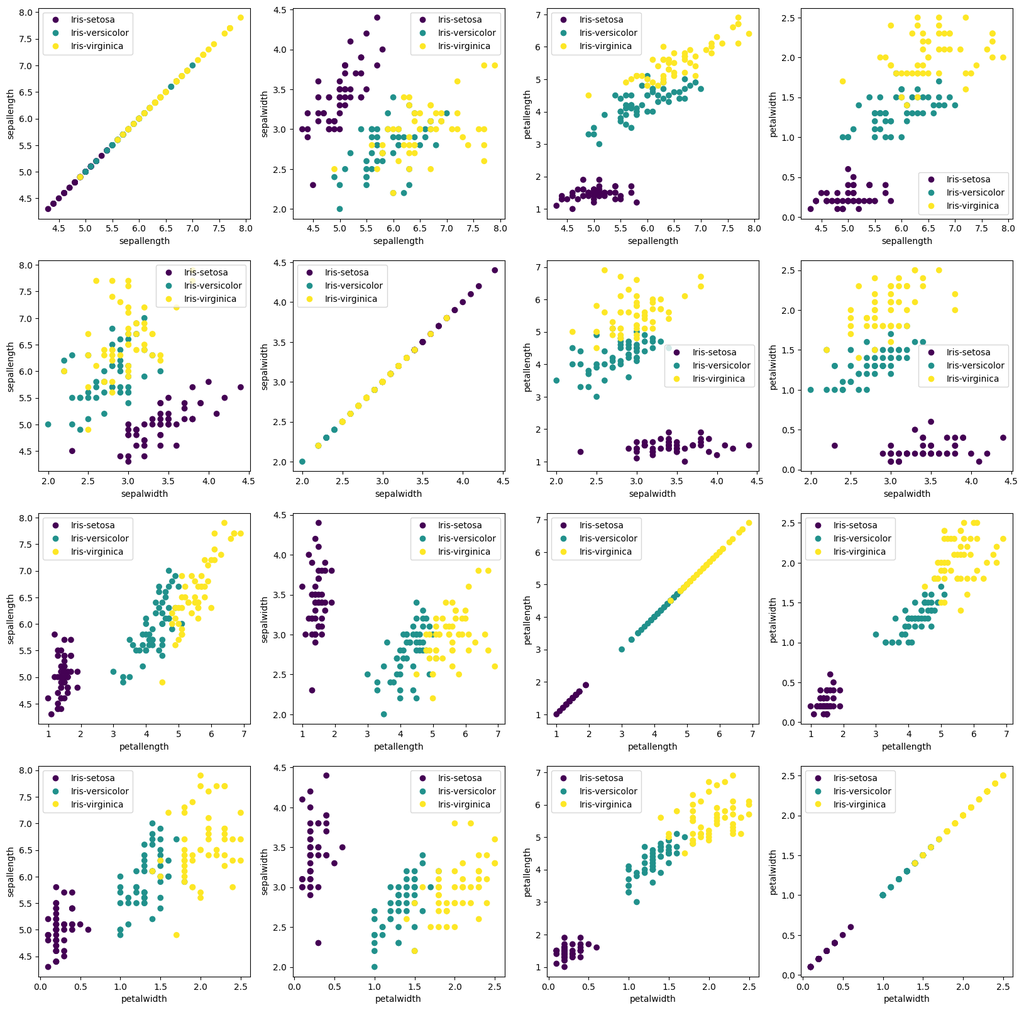

```python
fig,axes = plt.subplots(4,4,figsize = (20,20))
for ix in range(4):
    for iy in range(4):
        scatterplot = axes[ix,iy].scatter(iris_df.iloc[:,ix],iris_df.iloc[:,iy], c=iris_df['class'])
        axes[ix,iy].set_xlabel(iris_df.columns[ix])
        axes[ix,iy].set_ylabel(iris_df.columns[iy])
        axes[ix,iy].legend(handles=scatterplot.legend_elements()[0], labels=dict_names.values())
```

### Scatter plot with pandas

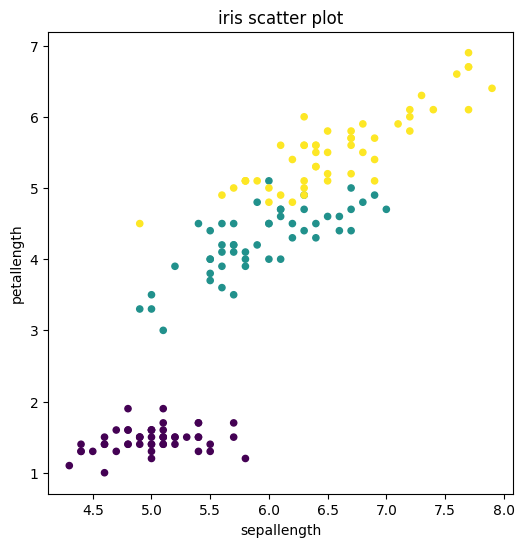

```python
iris_df.plot(x='sepallength',
             y='petallength',
             kind='scatter',
             c='class',
             colormap = 'viridis',
             colorbar = False,
             figsize=(6,6),
             title='iris scatter plot')
```

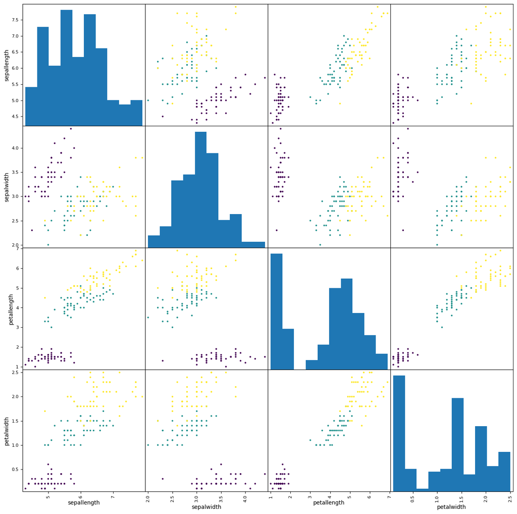

```python
from pandas.plotting import scatter_matrix
scatter_matrix(iris_df.drop('class',axis = 1),
               figsize = (16,16),
               alpha = 1,
               diagonal = 'hist',
               c = iris_df['class'])
plt.show()
```

### Plotting with Seaborn

```python
import seaborn as sns
```

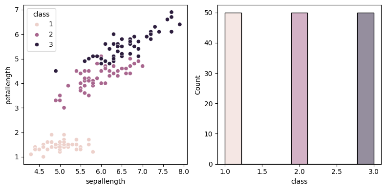

```python
f, axes = plt.subplots(1, 2, figsize=(8, 4))

sns.scatterplot(data=iris_df,
                x="sepallength",
                y="petallength",
                hue="class", # hue = Grouping variable that will produce points with different colors
                ax=axes[0])

sns.histplot(data=iris_df,
             x="class",
             hue="class",
             legend=False,
             ax=axes[1])
f.tight_layout()
```

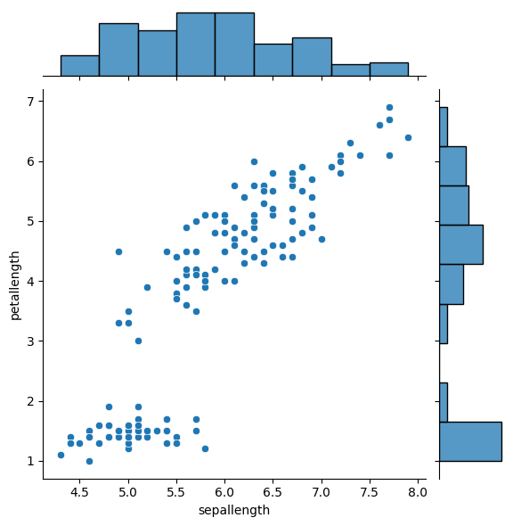

```python
sns.jointplot(data=iris_df, x="sepallength", y="petallength")
```

Assigning a hue variable will add conditional colors to the scatterplot and draw separate density curves on the marginal axes:

internally, it uses `kdeplot()`: it plots univariate or bivariate distributions using kernel density estimation.

- A **kernel density estimate** (KDE) plot is a method for visualizing the distribution of observations in a dataset, analagous to a histogram. KDE represents the data using a continuous probability density curve in one or more dimensions.

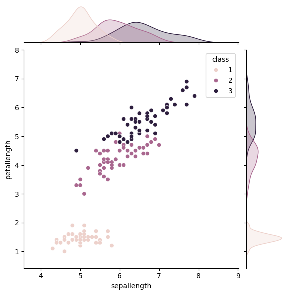

```python
sns.jointplot(data=iris_df, x="sepallength", y="petallength",hue = 'class')
```

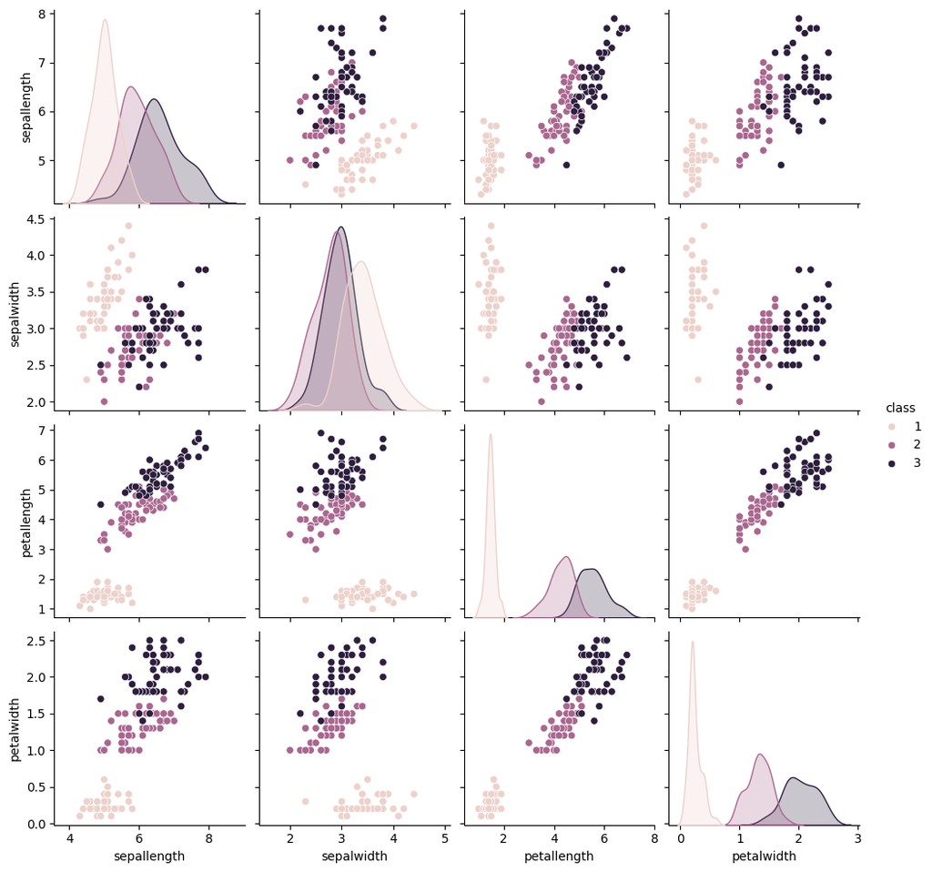

```python
sns.pairplot(data=iris_df, hue="class")
```

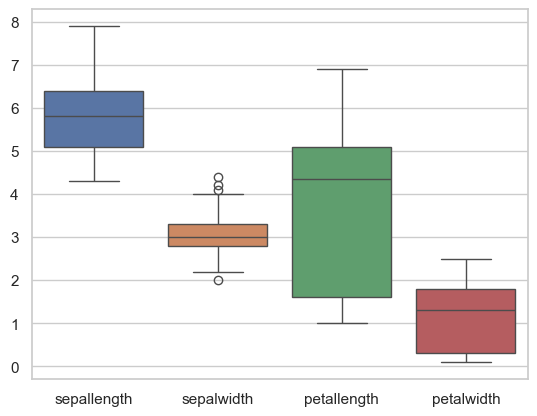

```python
sns.set_theme(style="whitegrid")
ax = sns.boxplot(data=iris_df.iloc[:,:-1], orient="v")
```

### Correlation Analysis

`SciPy` is a collection of mathematical algorithms and convenience functions built on the NumPy extension of Python. It adds significant power to the interactive Python session by providing the user with high-level commands and classes for manipulating and visualizing data.

SciPy features includes, but are not limited to:

- statistics
- linear algebra
- fourier transform
- optimization algorithm
- ...

```python
from scipy.stats import pearsonr
pearsonr(iris_df.sepallength,iris_df.sepalwidth)
```

```
PearsonRResult(statistic=-0.10936924995064932, pvalue=0.18276521527136966)
```

The `pearsonr` function returns:

- Pearson product-moment correlation coefficent.
- The p-value associated with the chosen alternative: it roughly indicates the probability of an uncorrelated system producing datasets that have a Pearson correlation at least as extreme as the one computed from these datasets.

Pearson correlation coefficient can also be obtained with `pandas.DataFrame.corr()`

```python
iris_df.drop('class',axis = 1).corr()
```

|  | sepallength | sepalwidth | petallength | petalwidth |
| --- | --- | --- | --- | --- |
| sepallength | 1.000000 | -0.109369 | 0.871754 | 0.817954 |
| sepalwidth | -0.109369 | 1.000000 | -0.420516 | -0.356544 |
| petallength | 0.871754 | -0.420516 | 1.000000 | 0.962757 |
| petalwidth | 0.817954 | -0.356544 | 0.962757 | 1.000000 |

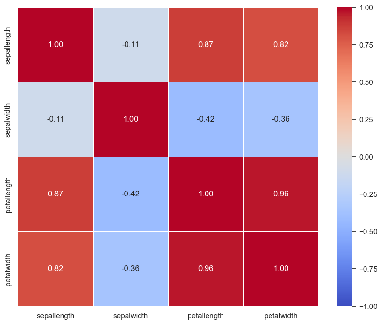

```python
f,ax = plt.subplots(figsize=(10, 8))
sns.heatmap(iris_df.drop('class',axis = 1).corr(),
            annot=True,
            linewidths=.5,
            fmt= '.2f',
            ax=ax,
            vmin=-1,
            vmax=1,
            cmap = "coolwarm")
plt.show()
```